# STOR 320 Tutorial on Workflow/ Visualization

Mario Giacomazzo

June 27, 2019

# Step-by-Step Image Building

In this tutorial, we will slowly construct the image below via `ggplot`. This chart was created using the `presidentialElections` dataset in the `pscl` package. These plots visually compare the historical change in the Democratic Vote between the former Confederate states and non-Confederate states.

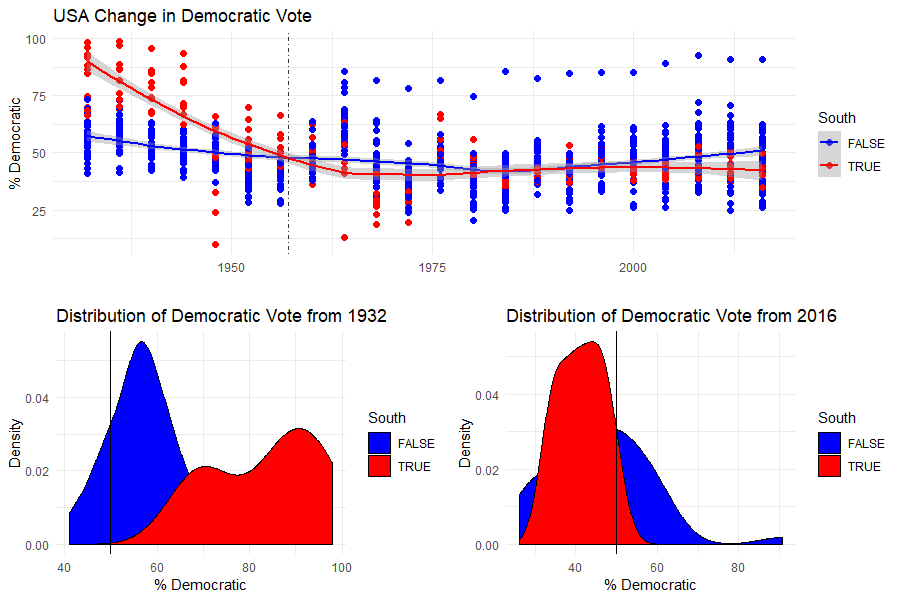

For ease, we start by reassigning the dataset `presidentialElections` to a new variable called `PE`.

```r
PE=presidentialElections
```

# Plot 1: Time Series Plot

### Step 1: Initiate Plot and Print

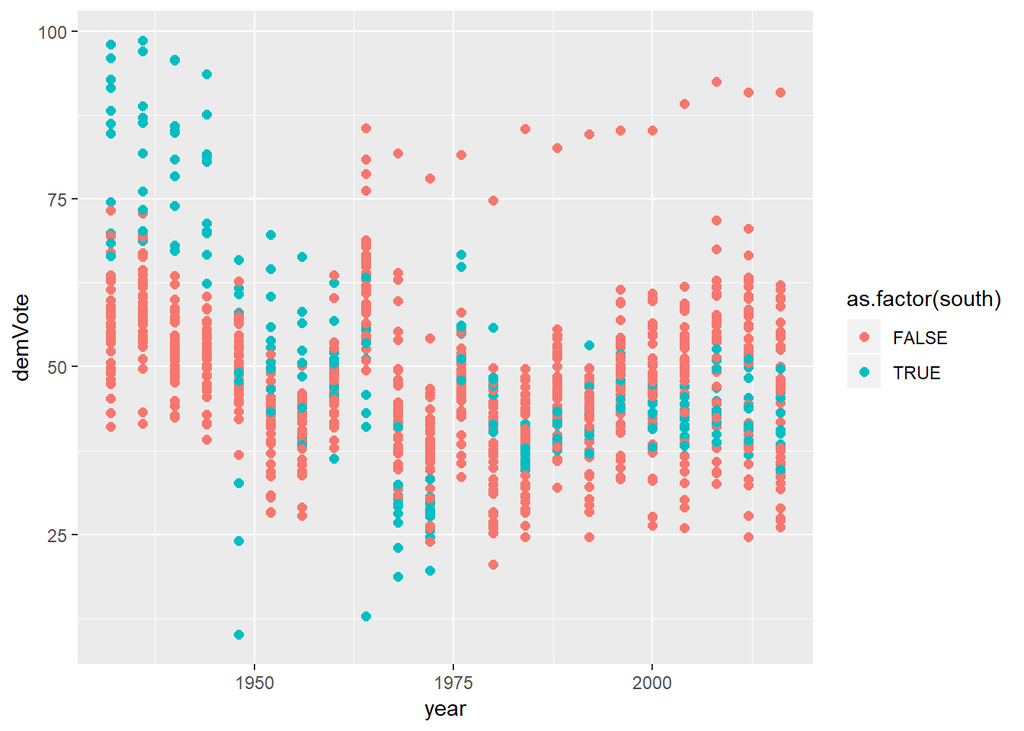

```r
p1<-ggplot(data=PE) +
  geom_point(aes(x=year,y=demVote,color=as.factor(south)),size=2)
p1
```

### Step 2: Modify the Title and Labels

Use `xlab()`, `ylab()`, and `ggtitle()`.

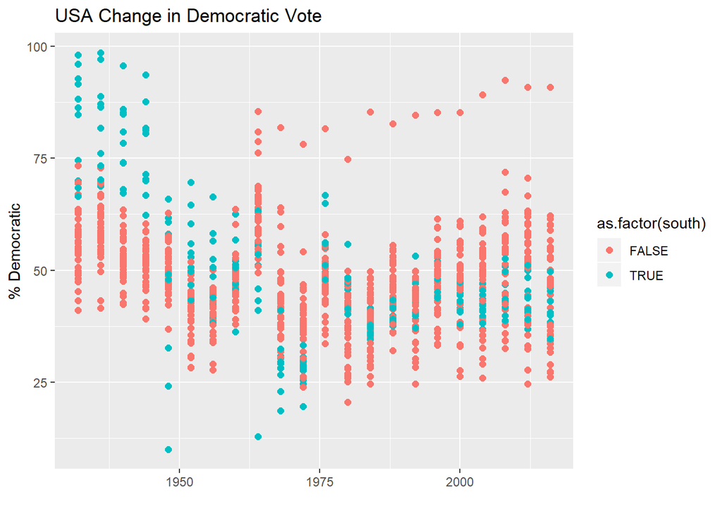

```r
p2<-p1+xlab("")+ylab("% Democratic")+ggtitle("USA Change in Democratic Vote")
p2
```

### Step 3: Get Smooth Curves and Print

Use `geom_smooth` similarly how we used `geom_point`.

```r
p3<-p2+geom_smooth(COMPLETE_INSIDE)
p3
```

### Step 4: Modify the Legend Title and Print

Since the legend is for the color aesthetic we use `guides(color=guide_legend(title=COMPLETE_INSIDE))` to rename the legend.

```r
p4<-p3+ COMPLETE
p4
```

### Step 5: Manually Select the Colors and Print

For the color aesthetic, we want to manually select the two different colors.

```r
p5<-p4+ scale_color_manual(values=c("COLOR 1","COLOR 2"))
p5
```

### Step 6: Reference Line and Print

It doesn’t seem to be until around 1957 where the non-Confederate states began to exceed the former Confederacy on approval for the Democratic party. We want to create a vertical line through the x-axis at 1957 using `geom_vline`. Check `?geom_vline` for more information about this geometric object.

For the color aesthetic, we want to manually select the two different colors.

```r
p6<-p5+geom_vline(MISSING_OPTION,alpha=0.8,linetype=4)
p6
```

### Step 7: Modify the Theme and Print

Use `theme_minimal()` for the plot.

```r
FINALPLOT1<-EDIT_INFORMATION
FINALPLOT1
```

# Plot 2: Overlapping Density Curves in 1932

### Step 1: Create Basic Density Plot

`PE$year` is a vector of all the years represented in the data for all states. `PE$year==1932`creates a vector of `TRUE` and `FALSE` where `TRUE` indicates observations from the year 1932. `PE[PE$year==1932,]` modifies the dataset to only include the data for the year 1932.

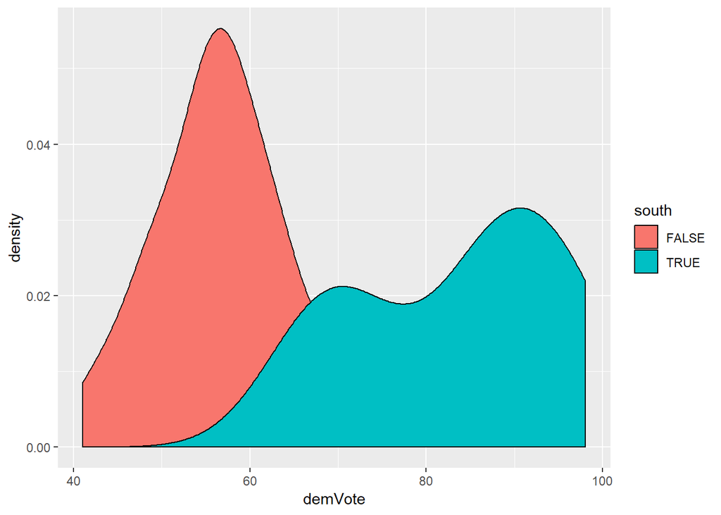

```r
p1<-ggplot(data=PE[PE$year==1932,]) +
      geom_density(aes(x=demVote,fill=south))
p1
```

### Step 2: Modify Plot and Print

Modify the legend, titles, color, theme similarly to how we did the first plot. Also, add a vertical line at 50 which indicates the transition to a majority vote.

```r
FINALPLOT2<-p1 + xlab("% Democratic") + ylab("Density") + etc......
FINALPLOT2
```

# Plot 3: Overlapping Density Curves in 2016

Repeat the code that created **FINALPLOT2** for the year 2016. I advise copy and paste.

```r
FINALPLOT3<- .......
FINALPLOT3
```

# Arrange All Plots in a Pleasant Layout

The `grid.arrange()` function from the `gridExtra` package allows us to do this. This needs to be done after all three plots are created. See if you can figure out what is going on

```r
#First Examine this Code and See What Happens

#Defaults to 1 Column Layout and Stacks Plots
grid.arrange(FINALPLOT1,FINALPLOT2,FINALPLOT3)

#Starts Placing Plots in a Two Column Layout
grid.arrange(FINALPLOT1,FINALPLOT2,FINALPLOT3,ncol=2)

#Now Check this Code Out: Try to Understand how the Matrix is Created and How the Layout is Controlled by the Matrix. Modify It to Get What I created
matrix(c(1,1,2,3),ncol=2)
LAYOUT=matrix(c(1,1,2,3),ncol=2)
grid.arrange(FINALPLOT1,FINALPLOT2,FINALPLOT3,layout_matrix=LAYOUT)
```